# GESTIÓ DE COMPTES LOCALS EN WINDOWS 11

@tofermos 2024

# 1. DES DE L’ENTORN GRÀFIC

Tot seguit observarem tres opcions per fer algunes gestions sobre usuaris. De totes, usarem la que ofereix la consola que veiem al següent subapartat(1.1) per la més completa i pràctica.

## 1.1 CONSOLA D’ADMINISTRACIÓ D’EQUIPS. (compmgmt.msc)

Des de l’entorn gràfic anem a *Panel de Control/Herramientas de Windows[¹]/Administrador de Equipos*.

En l’apartat de *Usuarios y grupos locales* d’esta consola disposarem de totes les ferramentes necessàries per a la gestió de comptes (usuaris i grups). És l’opció des d’on treballarem.

[figure not shown]

[figure not shown]

**Avanç**

> Les Microsoft Management Console (fitxers amb extensió *.msc*) són ferramentes gràfiques per a tasques d’administració i gestió dels sistemes operatius Windows.

> Podem trobar-les al directori d’instal·lació de Windows *c:\windows\system32*.

Per accedir directament a la Consola d’Adminsitració d’Equips:

[figure not shown]

## 1.2 ALTRES OPCIONS

Des del GUI podem fer algunes gestions amb els comptes d’usuaris amb altres opcions gràfiques…

### 1.2.1 Panel de Control. Administrar cuentas.

[figure not shown]

En esta opció veien que podem canviar el tipus de compte (Estàndar/Administrador) i poc més.

[figure not shown]

**Equivalències**

- El tipus per defecte “Estándard” equival al grup d’usuaris “Usuarios”.
- El tipus “Administradores” equival al grup d’usuaris “Administradores”

### 1.2.2 Ferramenta *netplwiz.exe*

Windows + R i executem **netplwiz**.

[figure not shown]

En esta opció ens mostra els noms de grups d’usuaris als quals pertany cada usuari. Ens permet afegir a algun grup distint d’Usuarios (Estándar) i Administradores però no podem crear grups nous.

[figure not shown]

**Avanç**

> Com podem observar a les imatges, cadascuna de les opcions gràfiques en execució genera un procés distint.

> A les imatges següents podem observar les tres alternatives gràfiques obertes al mateix temps i fixar-nos-hi en les **tasques >(procesos)** que s’hi veuen a l’*Administrador de Tasques*

[figure not shown]

# 2 USUARIS I GRUPS

## 2.1 Comptes per defecte

La instal·lació de Windows crea uns grups per defecte per al seu propi funcionament.

[figure not shown]

Ara ens centrarem en els dos principals que adés hem comentat:

- El Grup d’usuaris **Administradores**. Que tindran **drets** per realitzar qualsevol tasca que afecte a la configuració del sistema (SO, software, usuaris…) i **permisos** per a modificar carpetes i fitxers (crear, eliminar, modificar contingut, canviar de propietari o permisos…)
- El Grup **Usuarios** A diferència dels anteriors, no tindran drets per fer certes modificació sobre la configuració (com dnar d’alta un usuaris o instal·lar). I només podran fer modificacions sobre fitxers i carpetes de la seua propietat.

Estos dos grups equivalen al “tipo de cuenta”, *Administrador* i *Estándar* comentatas al punt 1.2

També Windows crear en la instal·lació comptes d’usuari, per defecte normalment inhabilitats, com *Administrador, Invitado o DefaulAccount*.

[figure not shown]

## 2.2 Nous comptes

A nosaltres ens pot interessar crear altres grups d’usuaris amb finalitats organitzatives; establir quines persones poden fer acciones sobre el software (per exemple, instala·lacions), la configuració (per exemple, crear un usuari) o poden fer modificacions en carpetes i fitxers.

El que hem de tenir en compte és que, si bé per defecte un usuari és *administrador* o *estándard* de forma exclusiva, podem crear nous grups i incloure-hi els usuaris que vullguem. Fixem-nos a la imatge següent. Observem que hem creat un grup “Familia” al qual hem afegit un usuari que pertany al grup “Administradores” ( Tomas) i també un usuari estandard del grup “Usuarios”

[figure not shown]

**Avanç**

> Un **permís** és una autorització que se li dóna a un usuari (o grup) sobre carpetes o fitxer per a poder: 1. Llegir o 2. Escriure o 3. Canviar els permisos (1 i 2) o el *propietari* > unes carpetes o fitxers

> El **propietari** és, per defecte, l’usuari que ha creat la carpeta o fitxer.

## 2.3 Acumulació de permisos de lectura, escriptura o canvi

Per tant, un mateix usuari pot pertànyer a més d’un grup. En estos casos, els permisos de cadascun dels grups als quals pertany se sumen. Ho estudiarem més avant.

# 3. VISIÓ DES DE L’INTERFACE DE COMANDAMENTS

Encara que en Windows11 serà més habitual treballar en l’entorn gràfic hem de tenir sempre present que disposem de dos shells o interface de comandaments:

- La consola de comandaments o cmd
- Powershell

En una unitat següent s’estudiarà com crear modificar comptes des d’estos entorns CLI. Ara, fem este avanç només per comprovar que els usuaris estan creats però el seu perfil ( carpetes encara no ).

## 3.1 Des de la consola CMD:

Pulsem *Win-R : cmd* i comprovem amb

[figure not shown]

```
net user
```

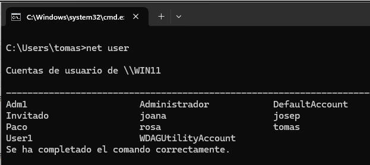

```
net localgroup
```

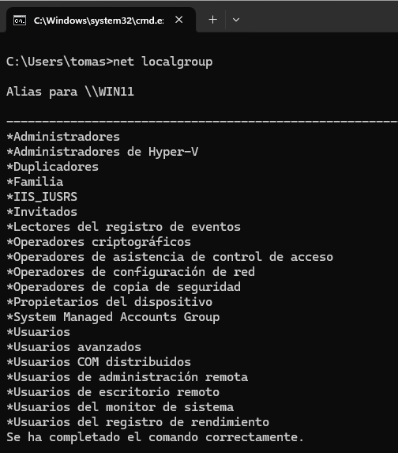

## 3.2 Des de Powershell

Amb *Win-R: powershell* o buscant

[figure not shown]

i comprovem amb

```powershell
get-LocalUser
```

[figure not shown]

```powershell
get-LocalGroup
```

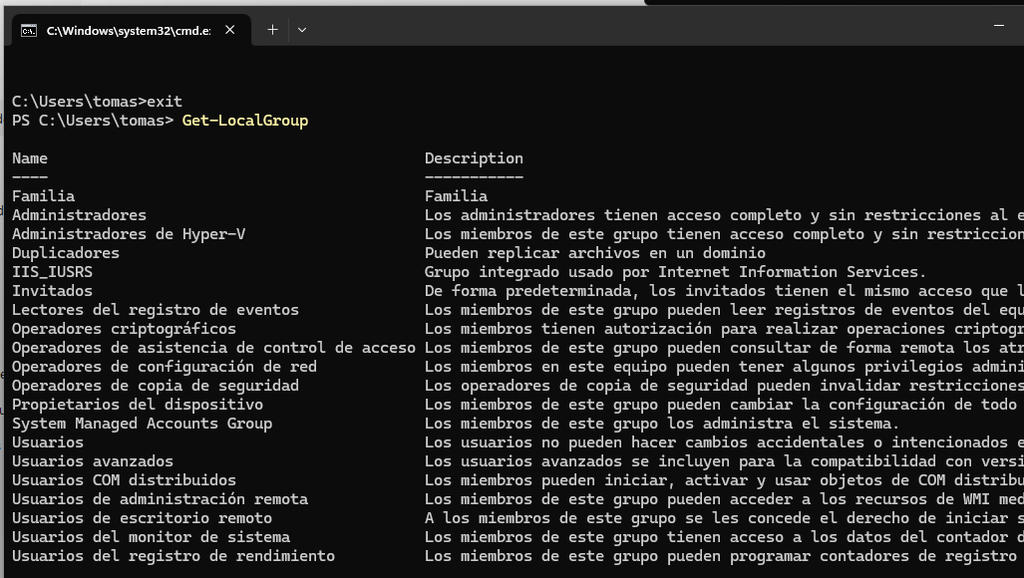

**Avanç**

> El Powershell és un potent shell de comandaments en línia amb un lleguatge per a desenvolupar scripts (.ps1). Teniu un repositori per aprendre’n més en este Git

# 4 VISIÓ AL REGISTRE del SISTEMA

Observem com es registra al Registre del sistema els perfils (profiles) de cada usuari.

**Avanç**

> El Registre del sistema (*C:\WINDOWS\regedit.exe*) és un component essencial de tots el sistemes Windows. Formalment és una base de >dades jeràrquica que emmagatzema configuracions i opcions del sistema operatiu i les aplicacions.

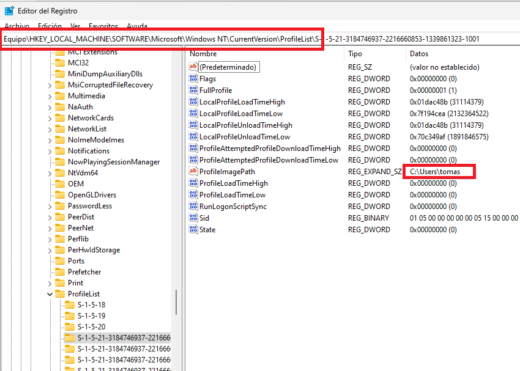

# 5 PERFIL DE L’USUARI

El perfil comprén tots els directoris ( “Els meus Documents, Descàrregues…”) i altres característiques que són exlusives de cada usuari o comuns.

Veiem les carpetes:

[figure not shown]

## 5.1 Creació del perfil

Segurament si hem creat un usuari nou, haurem comprovat en l’anterior punt que l’usuari acabat de crear:

- Apareix al GUI. Consola gràfica 8 compmgmt.msc ) i les altres opcions.
- Apareix al CLI. *net user* i *get-localuser*
- No apareix al registre del sistema la entrada a *ProfileList*
- No apareixen les carpetes de perfil personal a *C:\usuarios*

**NOTA**

> Quan es crea el perfil de l’usuari? El perfil dels usuaris ( c:\users|usuari\…es crea quan, una vegad creat, iniciem per primera vegada sessió amb ell. Notarem que el primer inici de sessió es fa molt lent, sobretot si no hem desactivat Cortana Com a nota podem avançar que en Linux veurem que ocorre el mateix.

Una vegada creat el perfil, podem entrar dins de la carpeta del nostre usuari i observar tres subcarpetes:

- Default
- Acceso Público
- Una carpeta específica per cada usuari

Cadascuna té una funció que veiem tot seguit.

## 5.2 Default

La carpeta **c:\users\Default** [^2] és una plantilla per a la creació de nous perfils d’usuari. Conté configuracions i arxius predeterminats que es copien a qualsevol nou compte d’usuari quan es crea. Ací es troben:

- **Configuracions del compte**: Preferències i configuracions d’aplicacions predeterminades.
- **Carpetes d’usuari predeterminades**: Documents, Imatges, Música, Vídeos, Escriptori, Descàrregues, etc.
- **Arxius de configuració**: Arxius de personalització de l’entorn d’usuari, com el fons d’escriptori, icones, accessos directes, etc.

Els nous usuaris de l’ordinador hereten estos arxius i configuracions la primera vegada que inicien sessió.

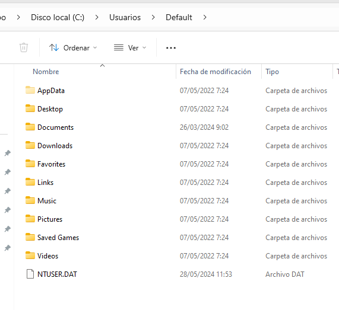

## 5.3 Acceso Público

La carpeta **Acceso Público** [^3] Carpeta compartida accessible per tots els usuaris de l’equip per compartir arxius sense cap restricció.

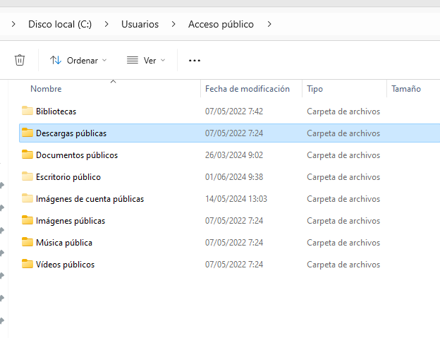

## 5.4 Carpeta de l’Usuari Específic

Cada usuari té la seva pròpia carpeta, que emmagatzema els seus arxius personals i configuracions específiques. Esta carpeta inclou:

- **Carpetes personals**: Documents, Imatges, Música, Vídeos, Escriptori, Descàrregues.
- **Configuracions d’usuari**: Configuracions específiques de l’usuari que afectaran a com pot usar el SO i aplicacions software.
- **Arxius i configuracions personals**: Qualsevol arxiu que l’usuari guarde a seues carpetes personals i també les configuracions personalitzades.

[figure not shown]

> Només podrem entrar a carpeta d’altres usuaris si som Administrador. Es proposa més avant una activitat per comprovar-ho.

# 6 Activitats

## Activitat 1

1. Des de la Consola gràfica, crea un usuari que pertanya al grup Administradores i un altre que no siga administrador i pertanyerà sols al grup d’usuaris:
- Adm1
- User1
2. Assegura’t que els dos usuaris hagen de canviar la contrassenya la primera vegada d’iniciar sessió en els dos usuaris.
3. Inicia sessió, amb l’usuari *Adm1*.

   3.1 Observa els continguts de les carpetes C:\Users\Adm1 i anota, si existeixen, qué contenen.

   3.2 Observa els continguts de les carpetes C:\Users\User1 i anota, si existeixen, qué contenen

   3.3 Crea un fitxer *Telefons.txt* a la carpeta personal de Adm1 C:\users\Public\Documents

   3.4 Crea una carpeta *Diari* a la carpeta C:\Users\Default\Desktop
4. Inicia sessió amb *User1*. Ara comprovarem l’efecte dels canvis fets adés en este usuari nou.

   4.1 Comprova si apareix la carpeta *Diari* a l’escriptori

   4.2 Està disponible C:\users\Public\Documents\Telefons.txt

   4.3 Entra al perfil de User1 C:\users\User1 i observa el contingut de les carpetes
5. Sense tancar sessió (sessió de *User1* ) intenta crear un grup d’usuaris amb el nom de *Botiga*

   5.1 Afig dins d’ell els dos usuaris *User1 i Adm1*

   5.2 Crea un tercer usuari estàndard *User2* i afig-lo al grup *Botiga*

   5.3 Descarrega’t un foto d’una botiga que usaran tots els usuaris. En quina creus deuries alçar-la tractant-se d’una imatge per compartir?